# Projekt 1 WdAD

Maja Witkowska

09 01 2022

## Analiza wczytanych danych

Aby zanalizować dane najpierw wczytujemy je, wybieramy tylko te które są potrzebne do naszej analizy oraz filtrujemy je tak, żeby wyświetlały się tylko dane dotycząca głowy rodziny.

```
## 'data.frame':    12698 obs. of  9 variables:
##  $ townsize  : chr  "villages" "town up to 19,999" "100,000 - 199,999" "500,000 and over" ...
##  $ wojregion : chr  "Malopolskie" "Lodzkie" "Dolnoslaskie" "Mazowieckie" ...
##  $ buildtype : chr  "free standing" "multi-flat" "multi-flat" "multi-flat" ...
##  $ flatsize  : int  80 18 29 28 53 24 50 20 46 65 ...
##  $ bills     : num  112 741 188 184 247 ...
##  $ sex       : chr  "male" "female " "female " "female " ...
##  $ educ      : chr  "primary" "primary" "primary" "high school" ...
##  $ married   : int  0 0 0 0 0 0 0 0 0 0 ...
##  $ billsmeter: num  1.4 41.15 6.48 6.56 4.67 ...
```

Zebrane dane dotyczą analizy budżetów gospodarstw domowych w roku 2015. Wybrane przeze mnie kolumny opisują odpowiednio: - wojregion: województwo w którym znajduje się gospodarstwo - buildtype: typ budowy domu (wolnostojący, bliźniak, dom wielomieszkaniowy, oraz „other” który został usunięty) - flatsize: powierzchnia domu (ze względu na to że w 3 domy miały wpisaną powierzchnię „0”, zostały one usunięte) - bills: rachunki - sex: płeć badanego - married: czy osoba badana jest w związku małżeńskim (1 - tak, 0 -nie) W poniższej analizie skupimy się głównie na typie budowy domu.

## Czy typ budownictwa wpływa na wielkość domu

Pierwsze - uważam że trywialne - zagadnienie które chcę sprawdzić to, jakie powierzchnie mają poszczególne rodzaje domów Za pomocą funkcji **summary** wyświetlamy Kwartyle, średnie, mediany oraz maksymalne i minimalne powierzchni domu w danych kategoriach.

```
## $`free standing`
##    Min. 1st Qu.  Median    Mean 3rd Qu.    Max.
##    6.00   60.00   80.00   86.12  100.00  400.00
##
## $`multi-flat`
##    Min. 1st Qu.  Median    Mean 3rd Qu.    Max.
##     9.0    37.0    48.0    48.5    57.0   240.0
##
## $`terrace/twin`
##    Min. 1st Qu.  Median    Mean 3rd Qu.    Max.
##   12.00   56.00   80.00   85.62  108.00  380.00
```

## Czy typ budownictwa wpływa na wysokość rachunków na metr kwadratowy

```
## $`free standing`
##    Min. 1st Qu.  Median    Mean 3rd Qu.    Max.
##   0.000   0.975   2.091   3.507   4.036  67.288
##
## $`multi-flat`
##    Min. 1st Qu.  Median    Mean 3rd Qu.    Max.
##   0.000   4.890   6.756   7.050   8.820  63.050
##
## $`terrace/twin`
##    Min. 1st Qu.  Median    Mean 3rd Qu.    Max.
##   0.000   1.357   2.625   3.762   4.830  56.092
```

Można zauważyć, że maksymalne i minimalne wartości są w miarę zbliżone (minimalne są równe 0, a w maksymalnych znaczną różnicę można zauważyć, w których bliźniakach rachunek jest tańszy od pozostałych), mediany i średnie są zbliżone do siebie w domach wolnostojących i bliźniakach, za to w domach wielomieszkaniowych są one znacznie droższe (około 4 zł).

## Jaki typ budownictwa dominuje w danych województwach

```
## # A tibble: 16 x 4
## # Groups:   wojregion [16]
##    wojregion           `free standing` `multi-flat` `terrace/twin`
##    <chr>                         <int>        <int>          <int>
##  1 Dolnoslaskie                    185          863             54
##  2 Kujawsko-pomorskie              186          408             23
##  3 Lodzkie                         342          661             41
##  4 Lubelskie                       394          267             26
##  5 Lubuskie                         96          195             22
##  6 Malopolskie                     453          504             44
##  7 Mazowieckie                     654         1013             97
##  8 Opolskie                        135          230              6
##  9 Podkarpackie                    330          244             23
## 10 Podlaskie                       186          198             21
## 11 Pomorskie                       141          493             60
## 12 Slaskie                         500         1141             39
## 13 Swietokrzyskie                  219          150             21
## 14 Warminsko-mazurskie             103          320             46
## 15 Wielkopolskie                   298          582             82
## 16 Zachodniopomorskie               75          448             79
```

Domy wolnostojące przeważają w województwach: - Lubelskim - Podkarpackie - Świętokrzyskim W reszcie województw przeważają mieszkania w domach wielomieszkaniowych. Bliźniaki nie przeważają w żadnym województwie i jest to najrzadszy typ (poza województwem zachodniopomorskim, gdzie taki typ przeważa nad domami wolnostojącymi).

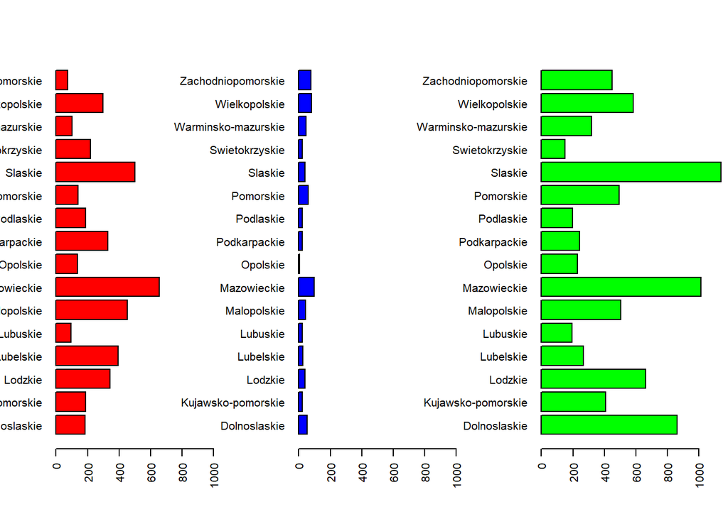

Wykresy pokazują liczbę danych typów budowy w poszczególnych województwach. Nie można jednak stwierdzić, że najwięcej budynków wolnostojących jest w województwie mazowieckim, ze względów na różne liczności badanych prób. Pokazują one za to, jaka jest różnica w ilościach danych typów budownictwa.

## Czy stan cywilny i płeć głowy rodziny ma wpływ na mieszkanie w danym typie domu

```
## # A tibble: 4 x 4
## # Groups:   marriedsex [4]
##   marriedsex  `free standing` `multi-flat` `terrace/twin`
##   <chr>                 <int>        <int>          <int>
## 1 "0 female "            1116         2910            198
## 2 "0 male"                473          984             63
## 3 "1 female "             595          961            106
## 4 "1 male"               2113         2862            317
```

Pierwsze co rzuca się w oczy to fakt, że jest mniej kobiet, które są głowami rodziny w małżeństwie niż mężczyzn. Najczęściej zamieszkanym typem domu w każdym wariancie jest mieszkanie w domu wielomieszkaniowym. Kiedy głową rodziny jest żonaty mężczyzna, częściej mieszkają oni w domach wolnostojących niż w przypadku gdy jest nią kobieta. W miarę podobnie kształtuje się zaś mieszkanie w bliźniaku. W przypadku osób niebędących w związku małżeńskim. W przypadku singli zależność jest podobna. Można więc zakładać, że to nie status cywilny, a płeć głowy rodziny wpływa na rodzaj domu gospodarstwa.